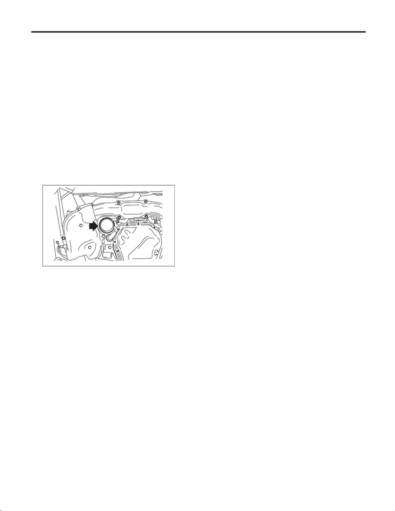

LU(STI)-29

Engine Oil Filter

LUBRICATION

9. Engine Oil Filter

A: REMOVAL

CAUTION:

If the engine oil is spilt over exhaust pipe or the

under cover, wipe it off with cloth to avoid emit-

ting smoke or causing a fire.

1) Lift up the vehicle.

2) Remove the under cover. <Ref. to EI-21, RE-

MOVAL, Front Under Cover.>

3) Remove the oil filter.

• Oil filter (Black)

Remove using the ST.

ST 18332AA000 OIL FILTER WRENCH (OUT-

ER DIAMETER: 68 MM (2.68

IN) FOR OIL FILTER)

• Oil filter (Blue)

Remove using a general tool (65/67 mm 14 Flutes).

B: INSTALLATION

CAUTION:

Do not tighten excessively, or oil may leak.

1) Clean the oil filter installation surface of the oil

cooler.

2) Obtain a new oil filter and apply a thin coat of en-

gine oil to the seal rubber.

3) Install the oil filter by turning it by hand, being

careful not to damage the seal rubber of the oil fil-

ter.

• Tighten the oil filter (black) with an outer diame-

ter of 68 mm (2.68 in) (approx. 1 rotation) after the

seal rubber of the oil filter comes in contact with oil

cooler. When using a torque wrench, tighten to 14

N·m (1.4 kgf-m, 10.3 ft-lb).

• Tighten the oil filter (blue) with an outer diameter

of 67.4 mm (2.65 in) (approx. 7/8 rotation) after the

seal rubber of the oil filter comes in contact with cyl-

inder block. When using a torque wrench, tighten to

12 N·m (1.2 kgf-m, 8.9 ft-lb).

4) Install the under cover. <Ref. to EI-22, INSTAL-

LATION, Front Under Cover.>

5) Lower the vehicle.

6) After installing, check the engine oil level and re-

plenish it if necessary. <Ref. to LU(STI)-11, IN-

SPECTION, Engine Oil.>

C: INSPECTION

1) After installing the oil filter, run the engine and

check for oil leakage around seal rubber.

NOTE:

The filter element and filter case are permanently

jointed; therefore, interior cleaning is not neces-

sary.

2) Check the engine oil level. <Ref. to LU(STI)-11,

INSPECTION, Engine Oil.>

LU-02707